# EDS 213 - Assignment 2.1 and 2.2

Steven Cognac

10/6/2021

USGS API sources - https://cran.r-project.org/web/packages/dataRetrieval/vignettes/dataRetrieval.html#daily-data - https://dashboard.waterdata.usgs.gov/app/nwd/?region=lower48&aoi=default

Metajam sources - https://brunj7.github.io/EDS-213-metadata/slides/metajam_intro.html#3

# **Assignment 2.1 - dataRetrieval**

## 2.1.1 Add the Santa Paula Creek guage to exercise we did in class

```r
siteNumber <- c(11118500, 11113500) # Ventura river and Santa Paula Creek USGS stations
parameterCd <- c("00060") # discharge & gauge height
startDate <- "2019-10-01" # use "" to grab entire data from beginning of recording
endDate <- "2021-10-11"


# create database based on above parameters
discharge <- readNWISdv(siteNumber, parameterCd, startDate, endDate) %>%
  mutate(river = case_when(site_no == "11118500" ~ "ventura_river",
                           site_no == "11113500" ~ "santa_paula_creek"))
```

## 2.1.2 What is the best way to query multiple sites using this R package?

**Best way to query multiple sites is to put all site numbers in a vector using the concatenate c() function.**

## 2.1.3 Create a plot showing any stream flow response to the rain of last night (10/04). Determine at what time did the stream flow peaked (if any) at the two locations?

- **Based on the data and graphs, the Ventura River had a slight peak on October 7. However, the river has a wide floodplain and is dammed less than 1 mile upstream from the Lake Casitas dam. As such, the flow is heavily regulated and minor discharge deviations in the Ventura River are unlikely a result of the rainstorm.**
- **The Santa Paula Creek is a smaller creek that’s not dammed and more likely influenced by storm events. Based on the data and graphs, Santa Paula Creek discharge peaked on October 8, 2021.**

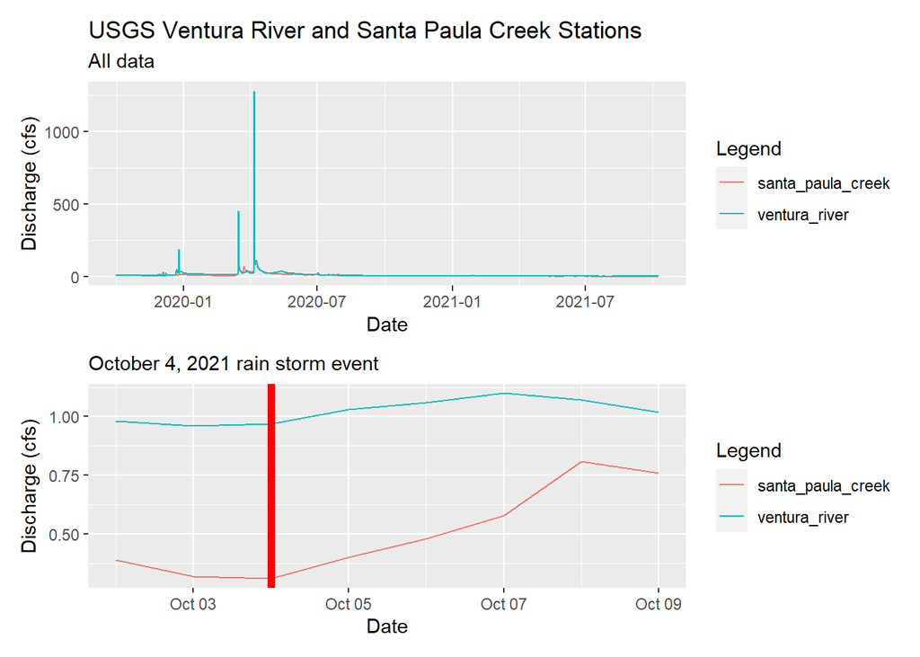

```r
# filter for stream guage dates after October 1, 2021
storm_discharge <- discharge %>%
  filter(Date >"2021-10-01")


# plot of all discharge data
all_discharge_plot <- ggplot(data = discharge, aes(x = Date, y = X_00060_00003, color = river)) +
  geom_line() +
  labs(x = "Date",
       y = "Discharge (cfs)",
       title = "USGS Ventura River and Santa Paula Creek Stations",
       subtitle = "All data",
       color = "Legend")


# plot of storm event stream discharge data after October 1, 2021
storm_plot <- ggplot(data = storm_discharge, aes(x = Date, y = X_00060_00003, color = river)) +
  geom_line() +
  labs(x = "Date",
       y = "Discharge (cfs)",
       subtitle = "October 4, 2021 rain storm event",
       color = "Legend") +
  geom_vline(xintercept = as.numeric(as.Date("2021-10-04")), color = "red", lwd = 2)


all_discharge_plot / storm_plot
```

# **Assignment 2.2 - metajam**

## 2.2.1 Finish the exercise we started during the lab session to use metajam to download the Alaskan household languages data from DataONE.

```r
# downloading data
data_url <- "https://knb.ecoinformatics.org/knb/d1/mn/v2/object/urn%3Auuid%3A7fc6f6db-c5ea-426a-a743-1f2edafb43b8"


# download csv files with metajam to folder titled "metajam" with the here() function
data_path <- download_d1_data(data_url, here("metajam"))
```

```
##
## urn:uuid:7fc6f6db-c5ea-426a-a743-1f2edafb43b8
## is the latest version for identifier
## urn:uuid:7fc6f6db-c5ea-426a-a743-1f2edafb43b8
```

```
## Download metadata complete
```

```
## Download complete
```

## read in .csv data with metajam

```r
# download the data based on the file path with metajam.
# creates a list of all data, which has pre-defined names
data <- read_d1_files(data_path)
# view metadata
data$attribute_metadata
```

```
## # A tibble: 50 x 11
##    attributeName  attributeDefinition      formatString measurementScale domain
##    <chr>          <chr>                    <chr>        <chr>            <chr>
##  1 Year           Year data were collected YYYY         dateTime         dateTi~
##  2 SASAP.Region   State of Alaska’s Salmo~ <NA>         nominal          textDo~
##  3 city           City that data were col~ <NA>         nominal          textDo~
##  4 lat            Latitude of city         <NA>         interval         numeri~
##  5 lng            Longitude of city        <NA>         interval         numeri~
##  6 total          Total population of cit~ <NA>         ratio            numeri~
##  7 speak_only_en~ Number of people in the~ <NA>         ratio            numeri~
##  8 german         Number of people in the~ <NA>         ratio            numeri~
##  9 yiddish        Number of people in the~ <NA>         ratio            numeri~
## 10 greek          Number of people in the~ <NA>         ratio            numeri~
## # ... with 40 more rows, and 6 more variables: definition <chr>, unit <chr>,
## #   numberType <chr>, missingValueCode <chr>,
## #   missingValueCodeExplanation <chr>, metadata_pid <chr>
```

## Write a piece of code that will compute the percentage of Alaskan household speaking only English for the year 2009 through 2015

```r
# get the dataframe
hh_data <- data$data
hh_data
```

```
## # A tibble: 3,142 x 50
##     Year SASAP.Region    city    lat   lng total speak_only_engl~ german yiddish
##    <dbl> <chr>           <chr> <dbl> <dbl> <dbl>            <dbl>  <dbl>   <dbl>
##  1  1990 Alaska Peninsu~ Adak~  NA     NA   4633             3630      8       0
##  2  1990 Kodiak          Akhi~  56.9 -154.    77               63      0       0
##  3  1990 Kuskokwim       Akia~  60.9 -161.   481               29      0       0
##  4  1990 Kuskokwim       Akiak  60.9 -161.   285               48      0       0
##  5  1990 Alaska Peninsu~ Akut~  54.1 -166.   589              250      8       0
##  6  1990 Yukon           Alak~  62.7 -165.   544              125      0       0
##  7  1990 Yukon           Alcan  62.7 -141.    27               15      2       0
##  8  1990 Bristol Bay     Alek~  59.3 -159.   185               76      0       0
##  9  1990 Yukon           Alla~  66.6 -153.   170               60      0       0
## 10  1990 Kotzebue        Ambl~  67.1 -158.   311               74      0       0
## # ... with 3,132 more rows, and 41 more variables: greek <dbl>, indic <dbl>,
## #   italian <dbl>, french_or_french_creole <dbl>,
## #   portuguese_or_portuguese_creole <dbl>, spanish_or_spanish_creole <dbl>,
## #   polish <dbl>, russian <dbl>, south_slavic <dbl>, arabic <dbl>,
## #   tagalog <dbl>, chinese <dbl>, hungarian <dbl>, japanese <dbl>,
## #   korean <dbl>, vietnamese <dbl>, other_and_unspecified_languages <dbl>,
## #   french_incl_patois_cajun <dbl>, french_creole <dbl>, ...
```

```r
# filter data for dates from 2009 to 2015. Group by year and region based on yearly means
alaska_data <- hh_data %>%
  filter(Year %in% c("2009", "2010", "2011", "2012", "2013", "2014", "2015")) %>%
  dplyr::rename(Region = "SASAP.Region") %>%
  group_by(Year, Region) %>%
  summarise(percent = (mean(speak_only_english, na.rm = TRUE) / (mean(total, na.rm = TRUE))) * 100)
alaska_data
```

```
## # A tibble: 91 x 3
## # Groups:   Year [7]
##     Year Region                                percent
##    <dbl> <chr>                                   <dbl>
##  1  2009 Alaska Peninsula and Aleutian Islands    34.7
##  2  2009 Arctic                                   45.9
##  3  2009 Bristol Bay                              66.3
##  4  2009 Chignik                                  86.2
##  5  2009 Cook Inlet                               81.0
##  6  2009 Copper River                             86.2
##  7  2009 Kodiak                                   64.6
##  8  2009 Kotzebue                                 58.3
##  9  2009 Kuskokwim                                27.7
## 10  2009 Norton Sound                             63.4
## # ... with 81 more rows
```

# plot of Alaskan household speaking only English for the years 2009 through 2015

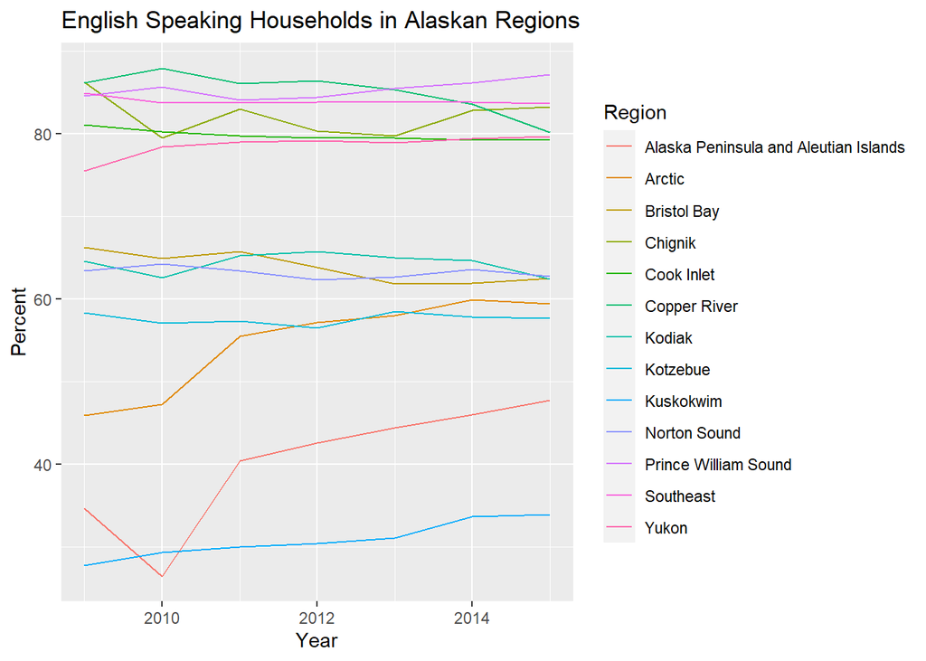

```r
alaska_standardized <- ggplot(data = alaska_data, aes(x = Year, y = percent)) +
  geom_line(aes(color = Region)) +
  labs(y = "Percent",
       title = "English Speaking Households in Alaskan Regions")

alaska_standardized
```